# **PRÁTICA ESTATÍSTICA II**

**ATIVIDADE AVALIATIVA 6: PROJETO I**  
Consumo de leites e derivados na pandemia de COVID-19

Guilherme Gomes Rodrigues (rodrigues_guilherme@id.uff.br)

Universidade Federal Fluminense

18/10/2026

# INTRODUÇÃO

## Contexto

- A pandemia
- Hábitos alimentares
- Leites e derivados
- A COVID-19 mudou a rotina da população: **isolamento social**, trabalho remoto e fechamento de comércios e serviços;
- Impactos **econômicos**: perda de renda e desemprego. Em 2022, **33,1 milhões de brasileiros** passavam fome (Rede PENSSAN, 2022);
- Impactos **emocionais**: no primeiro ano da pandemia, a prevalência mundial de **ansiedade e depressão aumentou 25%** (OMS, 2022).
- Mais tempo em casa mudou **como, quando e o que** se come;
- As mudanças podem ir em direções opostas: mais refeições preparadas em casa **ou** mais delivery e ultraprocessados;
- O acesso aos alimentos passou a depender ainda mais da **renda**.
- Fonte importante de **proteína e cálcio** na alimentação;
- Em 2022, o **leite longa vida acumulou alta de 57,4%** no ano até julho (IPCA-15, IBGE);
- Ou seja: um alimento básico ficou muito mais caro **justamente no ano da coleta dos dados**.

## Problema e objetivos

- Problema de pesquisa
- Objetivos

**Quais fatores estão associados às mudanças no consumo de leites e derivados durante a pandemia de COVID-19?**

- Variável resposta: **`Leites_Derivados`**, mudança no consumo de leites e derivados;
- Categorias: **Aumentou**, **Diminuiu**, **Não alterou** e **Não consumo**.

**Objetivo geral**

- Avaliar a associação entre a mudança no consumo de leites e derivados e as variáveis explicativas do banco de dados.

**Objetivos específicos**

- Investigar a relação com características **sociodemográficas e econômicas**;
- Avaliar fatores ligados à **pandemia e à saúde**;
- Avaliar a relação com a **saúde emocional**;
- Comparar **idade, peso, altura e IMC** entre as categorias de mudança.

# METODOLOGIA

## Os dados

- Origem
- Variável resposta
- Variáveis explicativas
- **Questionário online** aplicado em **2022**, durante a pandemia de COVID-19;
- Dados coletados por alunas da **pós-graduação em Nutrição da UFF**;
- **n = 2.155** adultos;
- Nenhum dado faltante nas variáveis analisadas.

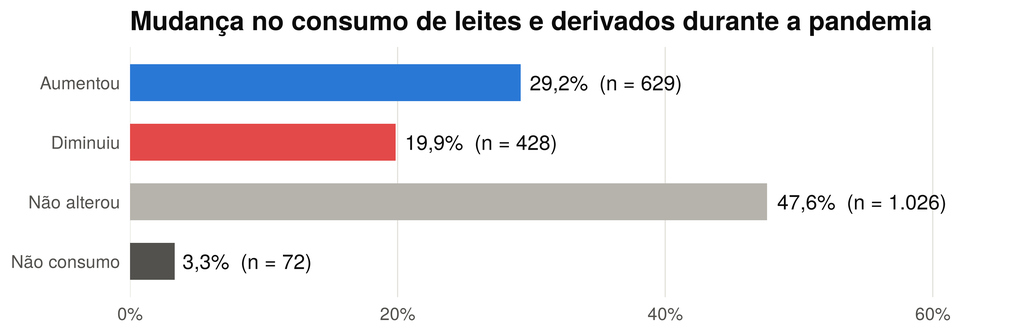

**Categóricas (15)**

- **Sociodemográficas:** gênero, raça/cor, região, escolaridade;
- **Socioeconômicas:** renda familiar, trabalho, dificuldade financeira;
- **Pandemia e saúde:** isolamento, COVID-19, nutricionista, fumo;
- **Saúde emocional:** ansiedade, depressão, insônia, enxaqueca.

**Quantitativas (4)**

- Idade (anos);
- Peso (kg);
- Altura (m);
- IMC (kg/m²).

## Tratamento dos dados

Categorias com **pouquíssimas observações** foram agrupadas ou excluídas, para garantir frequências esperadas adequadas no qui-quadrado:

| Variável | Ajuste | Excluídos |
| --- | --- | --- |
| Gênero | “Outro” (6) e “Prefiro não responder” (5) excluídos | 11 |
| Raça/cor | Amarela, Indígena e Outro agrupadas em **“Outras”** (39); “Prefiro não declarar” excluído | 28 |
| Escolaridade | Analfabeto, Fundamental e Médio agrupados em **“Até Ensino Médio”**; “Não desejo informar” excluído | 17 |

As exclusões valem apenas para o teste da própria variável. Nas demais análises, todos os 2.155 participantes foram mantidos.

## Métodos estatísticos

- Qui-quadrado
- V de Cramér
- Resíduos padronizados
- ANOVA de Welch
- Software
- Testa a **independência** entre a variável resposta e cada variável categórica;
- H₀: as variáveis são independentes; H₁: existe associação;
- **Suposições:** observações independentes e frequência esperada ≥ 5 em pelo menos 80% das caselas, sem nenhuma abaixo de 1;
- Se a suposição falhasse, seria usado o **teste exato de Fisher** (Monte Carlo). Após o tratamento dos dados, **todas as tabelas atenderam à suposição**.
- Mede a **intensidade** da associação, de 0 a 1;
- Necessário porque, com **n = 2.155**, até associações muito fracas ficam significativas;
- Referência usual de interpretação:

| V de Cramér | Até 0,10 | 0,10 a 0,30 | 0,30 a 0,50 | Acima de 0,50 |
| --- | --- | --- | --- | --- |
| Intensidade | Desprezível | Fraca | Moderada | Forte |

- O qui-quadrado diz **se** há associação; os resíduos mostram **onde** ela está;
- Resíduo padronizado ajustado com **|r| > 1,96** indica casela influente ao nível de 5%;
- Nas tabelas: **▲** mais casos que o esperado e **▼** menos casos que o esperado sob independência.
- Compara as **médias** de idade, peso, altura e IMC entre as 4 categorias da resposta;
- **Suposições:** independência e normalidade (com grupos grandes, garantida aproximadamente pelo TCL). **Não exige variâncias iguais**;
- Escolhida porque os grupos são **muito desbalanceados** (de 72 a 1.026 pessoas);
- Comparações múltiplas pelo teste de **Games-Howell**;
- Nível de significância: **α = 5%**;
- Análises feitas no **R**, com os pacotes:
  - `readxl`: leitura da base;
  - `dplyr` e `tidyr`: manipulação dos dados;
  - Games-Howell e teste de Levene: implementados em R base;
  - `ggplot2`: gráficos.

# RESULTADOS

## Variáveis qualitativas

- Sociodemográficas
- Socioeconômicas
- Pandemia e saúde
- Saúde emocional

Tabela 1 - Mudança no consumo de leites e derivados segundo variáveis sociodemográficas.

| Variável | Aumentou N = 629 | Diminuiu N = 428 | Não alterou N = 1.026 | Não consumo N = 72 | Total | *p*-valor | V de Cramér |
| --- | --- | --- | --- | --- | --- | --- | --- |
| **Gênero** |  |  |  |  |  | 0,054 | 0,060 |
| Feminino | 464 (29,0%) | 330 (20,6%) | 747 (46,6%) | 61 (3,8%) | 1.602 |  |  |
| Masculino | 161 (29,7%) | 94 (17,3%) | 276 (50,9%) | 11 (2,0%) | 542 |  |  |
| **Raça/cor** |  |  |  |  |  | **<0,001** | 0,075 |
| Branca | 364 (27,0%) ▼ | 247 (18,4%) ▼ | 684 (50,8%) ▲ | 51 (3,8%) | 1.346 |  |  |
| Parda | 197 (34,2%) ▲ | 112 (19,4%) | 250 (43,4%) ▼ | 17 (3,0%) | 576 |  |  |
| Preta | 50 (30,1%) | 52 (31,3%) ▲ | 63 (38,0%) ▼ | 1 (0,6%) ▼ | 166 |  |  |
| Outras | 10 (25,6%) | 9 (23,1%) | 17 (43,6%) | 3 (7,7%) | 39 |  |  |
| **Região** |  |  |  |  |  | **0,020** | 0,061 |
| Norte | 86 (28,2%) | 65 (21,3%) | 141 (46,2%) | 13 (4,3%) | 305 |  |  |
| Nordeste | 91 (34,0%) | 57 (21,3%) | 110 (41,0%) ▼ | 10 (3,7%) | 268 |  |  |
| Centro-Oeste | 54 (24,9%) | 36 (16,6%) | 120 (55,3%) ▲ | 7 (3,2%) | 217 |  |  |
| Sudeste | 282 (31,1%) | 172 (19,0%) | 434 (47,9%) | 19 (2,1%) ▼ | 907 |  |  |
| Sul | 116 (25,3%) ▼ | 98 (21,4%) | 221 (48,3%) | 23 (5,0%) ▲ | 458 |  |  |
| **Escolaridade** |  |  |  |  |  | **<0,001** | 0,106 |
| Até Ensino Médio | 200 (26,7%) | 205 (27,4%) ▲ | 316 (42,2%) ▼ | 27 (3,6%) | 748 |  |  |
| Ensino Superior Completo | 136 (32,7%) | 74 (17,8%) | 195 (46,9%) | 11 (2,6%) | 416 |  |  |
| Pós-graduação | 284 (29,2%) | 145 (14,9%) ▼ | 511 (52,5%) ▲ | 34 (3,5%) | 974 |  |  |

Frequência absoluta e percentual por linha. *p*-valor do teste qui-quadrado de independência; em negrito quando *p* < 0,05. Nas variáveis com associação significativa, as caselas destacadas têm resíduo padronizado ajustado com |r| > 1,96: ▲ mais casos que o esperado sob independência; ▼ menos casos.

Tabela 2 - Mudança no consumo de leites e derivados segundo variáveis socioeconômicas.

| Variável | Aumentou N = 629 | Diminuiu N = 428 | Não alterou N = 1.026 | Não consumo N = 72 | Total | *p*-valor | V de Cramér |
| --- | --- | --- | --- | --- | --- | --- | --- |
| **Renda familiar** |  |  |  |  |  | **<0,001** | 0,122 |
| Até R$ 1.254 | 58 (23,7%) ▼ | 87 (35,5%) ▲ | 91 (37,1%) ▼ | 9 (3,7%) | 245 |  |  |
| R$ 1.255 a R$ 8.640 | 374 (30,4%) | 253 (20,6%) | 567 (46,1%) | 36 (2,9%) | 1.230 |  |  |
| Mais de R$ 8.640 | 197 (29,0%) | 88 (12,9%) ▼ | 368 (54,1%) ▲ | 27 (4,0%) | 680 |  |  |
| **Trabalha** |  |  |  |  |  | **<0,001** | 0,138 |
| Sim | 470 (29,7%) | 264 (16,7%) ▼ | 798 (50,4%) ▲ | 51 (3,2%) | 1.583 |  |  |
| Não | 159 (27,8%) | 164 (28,7%) ▲ | 228 (39,9%) ▼ | 21 (3,7%) | 572 |  |  |
| **Dificuldade financeira** |  |  |  |  |  | **<0,001** | 0,307 |
| Sim | 92 (23,4%) ▼ | 179 (45,4%) ▲ | 110 (27,9%) ▼ | 13 (3,3%) | 394 |  |  |
| Não | 537 (30,5%) ▲ | 249 (14,1%) ▼ | 916 (52,0%) ▲ | 59 (3,4%) | 1.761 |  |  |

Frequência absoluta e percentual por linha. *p*-valor do teste qui-quadrado de independência; em negrito quando *p* < 0,05. Nas variáveis com associação significativa, as caselas destacadas têm resíduo padronizado ajustado com |r| > 1,96: ▲ mais casos que o esperado sob independência; ▼ menos casos.

Tabela 3 - Mudança no consumo de leites e derivados segundo fatores da pandemia e saúde.

| Variável | Aumentou N = 629 | Diminuiu N = 428 | Não alterou N = 1.026 | Não consumo N = 72 | Total | *p*-valor | V de Cramér |
| --- | --- | --- | --- | --- | --- | --- | --- |
| **Isolamento social** |  |  |  |  |  | **0,002** | 0,083 |
| Sim | 347 (28,8%) | 267 (22,2%) ▲ | 541 (45,0%) ▼ | 48 (4,0%) | 1.203 |  |  |
| Não | 282 (29,6%) | 161 (16,9%) ▼ | 485 (50,9%) ▲ | 24 (2,5%) | 952 |  |  |
| **Teve COVID-19** |  |  |  |  |  | 0,544 | 0,032 |
| Sim | 176 (30,2%) | 104 (17,8%) | 284 (48,7%) | 19 (3,3%) | 583 |  |  |
| Não | 453 (28,8%) | 324 (20,6%) | 742 (47,2%) | 53 (3,4%) | 1.572 |  |  |
| **Consultou nutricionista** |  |  |  |  |  | **<0,001** | 0,099 |
| Sim | 130 (31,9%) | 81 (19,9%) | 170 (41,7%) ▼ | 27 (6,6%) ▲ | 408 |  |  |
| Não | 499 (28,6%) | 347 (19,9%) | 856 (49,0%) ▲ | 45 (2,6%) ▼ | 1.747 |  |  |
| **Fuma** |  |  |  |  |  | 0,698 | 0,026 |
| Sim | 32 (30,5%) | 24 (22,9%) | 47 (44,8%) | 2 (1,9%) | 105 |  |  |
| Não | 597 (29,1%) | 404 (19,7%) | 979 (47,8%) | 70 (3,4%) | 2.050 |  |  |

Frequência absoluta e percentual por linha. *p*-valor do teste qui-quadrado de independência; em negrito quando *p* < 0,05. Nas variáveis com associação significativa, as caselas destacadas têm resíduo padronizado ajustado com |r| > 1,96: ▲ mais casos que o esperado sob independência; ▼ menos casos.

Tabela 4 - Mudança no consumo de leites e derivados segundo saúde emocional.

| Variável | Aumentou N = 629 | Diminuiu N = 428 | Não alterou N = 1.026 | Não consumo N = 72 | Total | *p*-valor | V de Cramér |
| --- | --- | --- | --- | --- | --- | --- | --- |
| **Ansiedade** |  |  |  |  |  | **0,002** | 0,082 |
| Sim | 317 (30,3%) | 234 (22,4%) ▲ | 457 (43,7%) ▼ | 38 (3,6%) | 1.046 |  |  |
| Não | 312 (28,1%) | 194 (17,5%) ▼ | 569 (51,3%) ▲ | 34 (3,1%) | 1.109 |  |  |
| **Depressão** |  |  |  |  |  | **<0,001** | 0,114 |
| Sim | 110 (31,5%) | 99 (28,4%) ▲ | 126 (36,1%) ▼ | 14 (4,0%) | 349 |  |  |
| Não | 519 (28,7%) | 329 (18,2%) ▼ | 900 (49,8%) ▲ | 58 (3,2%) | 1.806 |  |  |
| **Insônia** |  |  |  |  |  | **0,001** | 0,085 |
| Sim | 95 (32,5%) | 77 (26,4%) ▲ | 110 (37,7%) ▼ | 10 (3,4%) | 292 |  |  |
| Não | 534 (28,7%) | 351 (18,8%) ▼ | 916 (49,2%) ▲ | 62 (3,3%) | 1.863 |  |  |
| **Enxaqueca** |  |  |  |  |  | **0,030** | 0,064 |
| Sim | 99 (31,4%) | 78 (24,8%) ▲ | 130 (41,3%) ▼ | 8 (2,5%) | 315 |  |  |
| Não | 530 (28,8%) | 350 (19,0%) ▼ | 896 (48,7%) ▲ | 64 (3,5%) | 1.840 |  |  |

Frequência absoluta e percentual por linha. *p*-valor do teste qui-quadrado de independência; em negrito quando *p* < 0,05. Nas variáveis com associação significativa, as caselas destacadas têm resíduo padronizado ajustado com |r| > 1,96: ▲ mais casos que o esperado sob independência; ▼ menos casos.

## Intensidade das associações

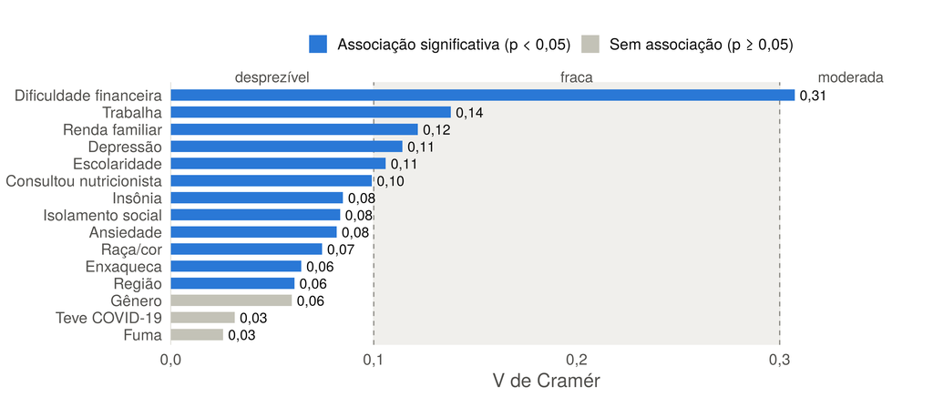

**Dificuldade financeira** é a única associação de intensidade **moderada**. As demais são fracas ou desprezíveis, mesmo quando significativas.

## Destaque: fatores socioeconômicos

- Dificuldade financeira
- Gradiente socioeconômico

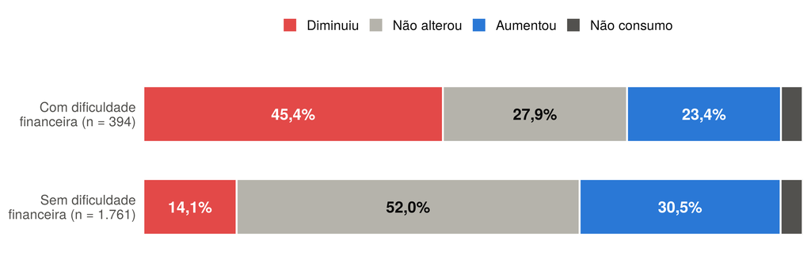

Entre quem relatou dificuldade financeira, **45,4% diminuíram** o consumo de leites e derivados, contra **14,1%** de quem não relatou. Resíduo ajustado de **+14,1**, o maior de todo o estudo.

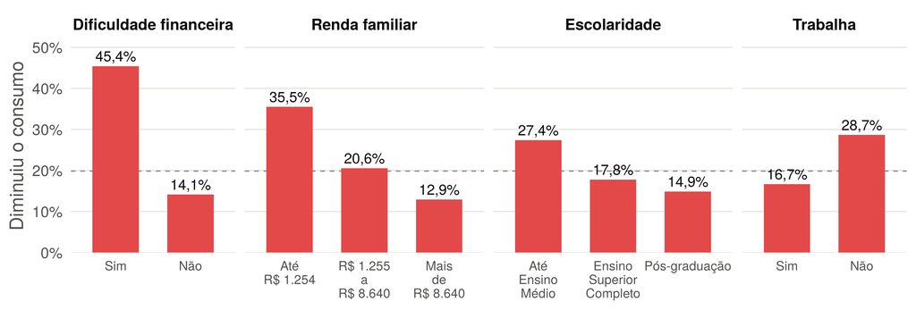

Linha tracejada: percentual geral que diminuiu o consumo (19,9%). Quanto **mais vulnerável** o grupo, **maior** a proporção que reduziu o consumo.

## Variáveis quantitativas

- Medidas resumo
- Comparações múltiplas

Tabela 5 - Variáveis quantitativas segundo a mudança no consumo de leites e derivados.

| Variável | Aumentou N = 629 | Diminuiu N = 428 | Não alterou N = 1.026 | Não consumo N = 72 | *p*-valor Welch | *p*-valor Levene |
| --- | --- | --- | --- | --- | --- | --- |
| **Idade (anos)** | 34,1 (12,2) 31,0 [24,0; 41,0] | 33,1 (12,2) 30,0 [23,0; 40,0] | 36,0 (12,7) 34,0 [25,0; 44,0] | 35,3 (13,1) 32,5 [23,0; 45,2] | **<0,001** | 0,140 |
| **Peso (kg)** | 72,1 (15,8) 70,0 [60,0; 82,0] | 69,8 (16,9) 67,0 [57,0; 79,0] | 69,6 (15,4) 67,6 [58,0; 79,0] | 66,0 (19,0) 59,5 [53,4; 74,8] | **0,003** | 0,278 |
| **Altura (m)** | 1,66 (0,09) 1,65 [1,60; 1,71] | 1,65 (0,09) 1,65 [1,59; 1,70] | 1,66 (0,08) 1,65 [1,60; 1,70] | 1,64 (0,08) 1,64 [1,60; 1,68] | 0,245 | 0,178 |
| **IMC (kg/m²)** | 26,2 (5,0) 25,6 [22,7; 28,9] | 25,4 (5,4) 24,5 [21,7; 27,9] | 25,3 (4,9) 24,5 [21,8; 28,1] | 24,5 (6,5) 22,7 [20,3; 26,7] | **0,004** | 0,139 |

Média (desvio-padrão); abaixo, mediana [1º quartil; 3º quartil]. *p*-valor da ANOVA de Welch (teste principal) e do teste de Levene para homogeneidade de variâncias. Em negrito quando *p* < 0,05.

Tabela 6 - Pares com diferença significativa no teste de Games-Howell.

| Variável | Comparação | Diferença de médias | IC 95% | *p* ajustado |
| --- | --- | --- | --- | --- |
| **Idade (anos)** | Aumentou vs Não alterou | -1,88 | [-3,50; -0,27] | **0,015** |
| **Idade (anos)** | Diminuiu vs Não alterou | -2,90 | [-4,73; -1,07] | **<0,001** |
| **Peso (kg)** | Aumentou vs Não alterou | 2,46 | [0,43; 4,50] | **0,010** |
| **IMC (kg/m²)** | Aumentou vs Não alterou | 0,85 | [0,20; 1,49] | **0,004** |

Diferença = média do primeiro grupo menos média do segundo. Apenas os pares com *p* ajustado < 0,05 são exibidos; os demais não diferiram. Altura não apresentou diferença na ANOVA de Welch.

## Interpretação dos resultados

- Socioeconômicas
- Emocionais
- Pandemia
- Sociodemográficas
- Quantitativas
- **Dificuldade financeira:** associação **moderada** (V = 0,31). Quem relatou dificuldade **diminuiu três vezes mais** o consumo (45,4% contra 14,1%);
- **Renda:** até R$ 1.254, **35,5% diminuíram**; acima de R$ 8.640, apenas **12,9%**;
- **Escolaridade:** até o Ensino Médio, **27,4% diminuíram**; na pós-graduação, **14,9%**;
- **Trabalho:** quem não trabalhava diminuiu mais (**28,7%** contra **16,7%**).
- **Depressão, insônia e ansiedade** associaram-se à resposta, com intensidade **fraca** (V entre 0,08 e 0,11);
- Quem relatou depressão diminuiu mais o consumo (**28,4%** contra **18,2%**) e manteve menos o hábito;
- **Enxaqueca** teve associação **desprezível** (V = 0,06).
- **Isolamento social:** associação fraca, com mais redução entre os isolados (**22,2%** contra **16,9%**);
- **Consulta com nutricionista:** quem consultou tem **mais que o dobro** de pessoas que **não consomem** (6,6% contra 2,6%);
- **Ter tido COVID-19** e **fumar** **não** se associaram à mudança.
- **Raça/cor:** pessoas pretas diminuíram mais o consumo (**31,3%** contra **18,4%** entre brancas);
- **Região:** associação desprezível (V = 0,06);
- **Gênero:** **não** houve associação (*p* = 0,054).
- **Idade:** quem **mudou** o consumo (aumentou ou diminuiu) é **mais jovem** do que quem não alterou;
- **Peso e IMC:** quem **aumentou** o consumo tem peso e IMC **maiores** do que quem não alterou (cerca de 2,5 kg e 0,8 kg/m² a mais);
- **Altura:** sem diferença entre os grupos;
- As diferenças são **pequenas** em termos práticos.

# CONCLUSÃO

## Principais achados

**Objetivo:** avaliar quais fatores se associam à mudança no consumo de leites e derivados durante a pandemia.

- Quase metade da amostra **não alterou** o consumo (47,6%); **29,2% aumentaram** e **19,9% diminuíram**;
- **12 das 15** variáveis categóricas e **3 das 4** quantitativas apresentaram associação ao nível de 5%;
- A **dificuldade financeira** foi o fator mais forte, e o **único** de intensidade moderada;
- A redução do consumo se concentrou nos grupos **mais vulneráveis**: menor renda, menor escolaridade, sem trabalho e pessoas pretas.

## Discussão

- O fator renda
- Saúde emocional
- Significância × relevância
- O padrão é coerente com a **alta de 57,4% no preço do leite longa vida** em 2022;
- Com o preço em alta, leite e derivados viram **candidatos naturais a corte** em um orçamento apertado;
- A associação com raça/cor provavelmente reflete a **desigualdade de renda** no Brasil, e não um efeito próprio da raça.
- Depressão, insônia e ansiedade associaram-se à **redução** do consumo;
- Porém, essas condições também estão ligadas à **dificuldade financeira**;
- Uma análise **bivariada** não separa esses efeitos: parte dessa associação pode ser explicada pela renda.

Com **n = 2.155**, até diferenças muito pequenas viram “significativas”.

- A maioria das associações tem **V < 0,15**: existem, mas são **fracas**;
- Por isso o **V de Cramér** e os **resíduos** foram essenciais para separar o que é **relevante** do que é apenas estatisticamente detectável.

## Limitações

- **Estudo transversal:** mostra associação, mas **não causalidade**. Não dá para saber, por exemplo, se o aumento do consumo levou ao maior IMC;
- **Amostra por conveniência** (questionário online): tende a super-representar pessoas com **alta escolaridade** e acesso à internet (45% com pós-graduação);
- **Dados autorrelatados**, sujeitos a viés de memória;
- **Muitos testes simultâneos** (19): com correção de Bonferroni (α = 0,0026), região, enxaqueca, peso e IMC deixariam de ser significativos;
- **Análises bivariadas**, sem controle de fatores de confusão. Uma regressão multinomial seria o próximo passo.

## Referências

1. IBGE. **Índice Nacional de Preços ao Consumidor Amplo 15 (IPCA-15): julho de 2022**. Rio de Janeiro: IBGE, 2022. Dados divulgados em: CANAL RURAL. Preço do leite subiu 57% em 2022, aponta IBGE. 2022.
2. REDE PENSSAN. **II Inquérito Nacional sobre Insegurança Alimentar no Contexto da Pandemia da COVID-19 no Brasil (II VIGISAN)**. São Paulo: Fundação Friedrich Ebert; Rede PENSSAN, 2022.
3. WORLD HEALTH ORGANIZATION. **COVID-19 pandemic triggers 25% increase in prevalence of anxiety and depression worldwide**. Genebra: WHO, 2 mar. 2022.
4. AGRESTI, A. **Categorical data analysis**. 3. ed. Hoboken: Wiley, 2013.
5. COHEN, J. **Statistical power analysis for the behavioral sciences**. 2. ed. Hillsdale: Lawrence Erlbaum, 1988.
6. WELCH, B. L. On the comparison of several mean values: an alternative approach. **Biometrika**, v. 38, n. 3/4, p. 330-336, 1951.
7. GAMES, P. A.; HOWELL, J. F. Pairwise multiple comparison procedures with unequal *n*’s and/or variances: a Monte Carlo study. **Journal of Educational Statistics**, v. 1, n. 2, p. 113-125, 1976.
8. R CORE TEAM. **R: a language and environment for statistical computing**. Viena: R Foundation for Statistical Computing, 2025.

**Obrigado!**

Guilherme Gomes Rodrigues